# Pressure1D_Implicit_ans

### Jupyter Labの使い方Tips

#### **esc +**

esc + MでMarkdown，esc + Yでコード，esc + A/Bで現在のセルの上/下にセルを追加，esc + Xでセルをカット

#### **その他**

JupyterLabのメニュー「View」→「Show Line Numbers」にチェックを入れると、行番号が表示

Edit > Clear all outputで全てのセルの出力をクリア

# **1次元圧力拡散方程式**

ここでは陰解法による1次元圧力拡散方程式を解くプログラム作成を目指す。離散化手法は陰解法を採用し，離散化式の単位を流量とする。

## **支配方程式**

密度が一定の，1次元で水平方向に広がる帯水層の質量保存則は
$$ \rho \phi\left( \frac{1}{\rho}\frac{\partial \rho}{\partial P}+\frac{1}{\phi}\frac{\partial \phi}{\partial P} \right) \frac{\partial P}{\partial t} = \rho\frac{\partial}{\partial x}\frac{k}{\mu}\frac{\partial P}{\partial x}+\frac{\tilde{m}}{V}\tag{1} $$
となる。$\tfrac{1}{\rho}\frac{\partial \rho}{\partial P}+\frac{1}{\phi}\frac{\partial \phi}{\partial P}=c$（圧縮係数）とおき，両辺を密度$\rho$で除算すると，
$$ \phi c \frac{\partial P}{\partial t} = \frac{\partial}{\partial x}\frac{k}{\mu}\frac{\partial P}{\partial x}+\frac{Q}{V}\tag{2} $$
以下式(2)を離散化して解く

## **問題設定**

1次元の圧力拡散方程式を解くが，下図のように断面積Aを持つ直方体状の帯水層を想定する。

[figure not shown]

## **離散化**

$i$ 番目のグリッドにおける離散化式を導出する。グリッドの体積 $V$ を両辺にかけて

$$ V\phi c \frac{\partial P}{\partial t} = V\frac{\partial}{\partial x}\frac{k}{\mu}\frac{\partial P}{\partial x}+Q\tag{3} $$

を得る。ただし，$Q$ はソース/シンク項で，坑井による注水/揚水に相当する。

[貯留層解析](https://te288.github.io/intro_to_NA2022/textbook/04_intro2ReservoirSim.pdf)で説明した通り，陰解法の場合式(3)の両辺は
$$ V\phi c \frac{\partial P}{\partial t}=\phi c A\Delta x \frac{P^{\left(n+1\right)}_{i}-P^{\left(n\right)}_{i}}{\Delta t}\tag{4} $$

$$ V\frac{\partial}{\partial x}\frac{k}{\mu}\frac{\partial P}{\partial x}+Q= \left.\frac{kA}{\mu\Delta x}\right|_{i+\frac{1}{2}}\left(P^{\left(n+1\right)}_{i+1}-P^{\left(n+1\right)}_{i}\right)- \left.\frac{kA}{\mu\Delta x}\right|_{i-\frac{1}{2}}\left(P^{\left(n+1\right)}_{i}-P^{\left(n+1\right)}_{i-1}\right) + Q_i\tag{5} $$

式(4)と式(5)をまとめて整理すると

$$ -\left.\frac{kA}{\mu\Delta x}\right|_{i+\frac{1}{2}}P^{\left(n+1\right)}_{i+1} + \left(\left(\frac{kA}{\mu\Delta x}\right|_{i+\frac{1}{2}} +\left.\frac{kA}{\mu\Delta x}\right|_{i-\frac{1}{2}}+\left(\frac{\phi c V }{\Delta t}\right)\right)P^{\left(n+1\right)}_{i}-\left.\frac{kA}{\mu\Delta x}\right|_{i-\frac{1}{2}}P^{\left(n+1\right)}_{i-1}= \frac{\phi c V }{\Delta t}P^{\left(n\right)}_i + Q \tag{6} $$

### !確認

$0$ と $N-1$ 番目のグリッドについて，不透水/圧力一定 $\left(P=P_b\right)$ 境界の場合の離散化式は？

### 問題

実際のプログラミングでは， $$ \left.\frac{kA}{\mu\Delta x}\right|_{i\pm\frac{1}{2}} $$ の計算で$k_i$と$k_{i\pm1}$の調和平均を計算する必要がある。調和平均の定義は $$ x_H = \dfrac{1}{\frac{1}{n}\left(\frac{1}{x_1}+\frac{1}{x_2}+...+\frac{1}{x_{n-1}}+\frac{1}{x_{n}}\right)} $$ ところが２つのデータ`a`，`b`の調和平均`2/(1/a+1/b)` では`a`，`b`のどちらかが`0`であるとき，Pythonでは

```python
a = 10; b = 0;
2/(1/a + 1/b)
```

```
---------------------------------------------------------------------------
ZeroDivisionError                         Traceback (most recent call last)
Input In [28], in <cell line: 2>()
      1 a = 10; b = 0;
----> 2 2/(1/a + 1/b)

ZeroDivisionError: division by zero
```

のようにエラーとなってしまう。このエラーを発生させない為には，どのようなコードを書けばよいだろうか？

### 解答

$$ x_H = \frac{1}{ \frac{1}{2}\left(\frac{1}{a}+\frac{1}{b}\right) } = \frac{2ab}{a+b} $$ と変形すれば，`0`除算を回避できる。

```python
2*(a*b)/(a+b)
```

```
0.0
```

## **実装**

```python
## Import Modules & Plot function
import numpy as np
from scipy.stats import hmean
from scipy.sparse import spdiags
import matplotlib.pyplot as plt

def SavePlot(x, P, t, L):
  # Function to Plot & Save Pressure
  # fig = plt.figure()
    plt.plot(x, P_new, label='t={0:05.2f}'.format(t))
    plt.xlabel('x[m]')
    plt.ylabel('Pressure [Pa]')
    plt.xlim(0, L)
    #plt.ylim(-1, 1)
    plt.grid()
    plt.title('Aquifer Pressure@{0:05.2f}[s]'.format(t))
  # fig.savefig('t={0:05.2f}.png'.format(t)) #画像保存には20行目と21行目も実行
  # plt.clf()
```

```python
def SaveCountourOf1Ddata(P, t, L, W, Pmin, Pmax,n, saveflag):
    plt.imshow([P_new, P_new], extent = [0, L, 0, W], cmap = 'jet', vmin=Pmin, vmax=Pmax)
    plt.xlabel('L[m]')
    plt.ylabel('W[m]')
    plt.title("Aquifer Pressure [Pa]@ {:08.2f}days".format(t/86400))
    plt.colorbar(aspect = 20, orientation= 'horizontal', shrink=1)
    if saveflag:
        fig.savefig('result/AquiferPressure{:08.2f}days.png'.format(t/86400), facecolor="white") #画像保存には20行目と21行目も実行%filename に＠や[]はつけない
    plt.clf()
```

```python
## Input Parmeters
# time step & boundary condition controll
dt   = 43200   # dt [s] 43200[s] is equal to 0.5 days
tmax = 43200*2*365.25/2 # Time to stop simlation [s]
nout = 6  # output result ever nout step[]
saveflag = False # flag to save contour map
# Variable to decide Boundary condition
#  1> Neumann, 0> Dirichlet
BC_east = 0 # Boundary at right(x = L)
BC_west  = 0 # Boundary at Left (x = 0)
Pb_east = 0 # Pressure Value at x = L
Pb_west  = 0 # Pressure Value at x = 0

# Aquifer Geometory & coordinate
L   = 3000     # Length of theReservoir [m]
W   = 1000          # Width of the Reservoir [m]
h   = 10         # Tickness of the Reservoir [m]
N   = 100         # Number of Control Volume [-]
dx  = L/N         # Length of Control Volume[m]
A   = W*h           # cross-sectional area of reservoir [m^2]
x   = np.zeros(N) # x coordinate[m]
# Coordinate points of CV-center
x[0]= dx/2
for i in range(1, N):
    x[i] = x[i-1] + dx

# Aquifer Properties
perm   = 1e-1*np.ones(N)    # Absolute Permiability Field [m^2]
phi    = 0.3*np.ones(N)  # Porosity Field [-]
#P_init = np.abs(np.sin(x))     # Initial Condition of Pressure [Pa]
P_init = 1e6*np.ones(N)

# Fluid Properties
c    = 1     # Compressibility[Pa^-1]
mu   = 1     # Viscosity of Fluid[Pa*s]

# Well Parameters
Q   = np.zeros(N) # Source vector[m^/s]
# Q[3] = 0.05 # > 0, Injection wells
# Q[5] = -0.05 # < 0, Pumping wells
```

```python
## definition of Matrix for Linear simultaneous Eq.
T  = np.zeros([N,N]) # transmissibility Matrix
B   = np.zeros([N,N]) # Volume accumulation Matrix

# T
for i in range(0, N):
    if i == 0:
        Tw = 0
        Te = A/(mu*dx)*(2*( perm[i] * perm[i+1] )/( perm[i] + perm[i+1]) )
        T[i,i] = Tw + Te;
        T[i,i+1] = -Te
    elif i == N-1:
        Tw = A/(mu*dx)*(2*( perm[i-1] * perm[i] )/( perm[i-1] + perm[i]) )
        Te = 0
        T[i,i]    = Tw + Te;
        T[i, i-1] = -Tw
    else:
        Tw = A/(mu*dx)*(2*( perm[i-1] * perm[i] )/( perm[i-1] + perm[i]) )
        Te = A/(mu*dx)*(2*( perm[i] * perm[i+1] )/( perm[i] + perm[i+1]) )
        T[i,i] = Tw + Te;
        T[i,i-1] = -Tw
        T[i,i+1] = -Te

# B
for i in range(0, N):
    B[i,i] = A*dx*phi[i]*c

# Boundary Condition and Q
if BC_east == 0:
    Q[0] = 2*T[0,0]*Pb_east
    T[0,0] = T[0,0] + T[0,0];
if BC_west == 0:
    Q[N-1] = 2*T[N-1, N-1]*Pb_west
    T[N-1,N-1] = T[N-1,N-1] + T[N-1,N-1]
```

```
6th Time step , day03.00
12th Time step , day06.00
18th Time step , day09.00
24th Time step , day12.00
30th Time step , day15.00
36th Time step , day18.00
42th Time step , day21.00
48th Time step , day24.00
54th Time step , day27.00
60th Time step , day30.00
66th Time step , day33.00
72th Time step , day36.00
78th Time step , day39.00
84th Time step , day42.00
90th Time step , day45.00
96th Time step , day48.00
102th Time step , day51.00
108th Time step , day54.00
114th Time step , day57.00
120th Time step , day60.00
126th Time step , day63.00
132th Time step , day66.00
138th Time step , day69.00
144th Time step , day72.00
150th Time step , day75.00
156th Time step , day78.00
162th Time step , day81.00
168th Time step , day84.00
174th Time step , day87.00
180th Time step , day90.00
186th Time step , day93.00
192th Time step , day96.00
198th Time step , day99.00
204th Time step , day102.00
210th Time step , day105.00
216th Time step , day108.00
222th Time step , day111.00
228th Time step , day114.00
234th Time step , day117.00
240th Time step , day120.00
246th Time step , day123.00
252th Time step , day126.00
258th Time step , day129.00
264th Time step , day132.00
270th Time step , day135.00
276th Time step , day138.00
282th Time step , day141.00
288th Time step , day144.00
294th Time step , day147.00
300th Time step , day150.00
306th Time step , day153.00
312th Time step , day156.00
318th Time step , day159.00
324th Time step , day162.00
330th Time step , day165.00
336th Time step , day168.00
342th Time step , day171.00
348th Time step , day174.00
354th Time step , day177.00
360th Time step , day180.00
```

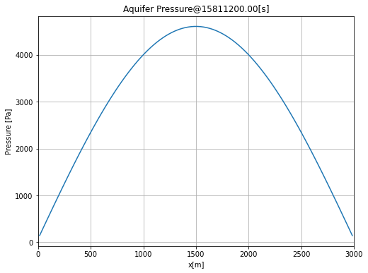

```python
## Simulation
P_old  = np.copy(P_init) # Pressure at n-th step
P_new  = np.copy(P_init) # Pressure at n+1-th step
t = 0
n = 0
fig = plt.figure(figsize=(8.0, 6.0))
Pmax = np.max([np.max(P_init), Pb_east, Pb_west])
Pmin = np.min([np.min(P_init), Pb_east, Pb_west])

# Plot Initial Condition
#SavePlot(x, P_new, t, L)
SaveCountourOf1Ddata(P_init, t, L, W, Pmin, Pmax, n, saveflag)
while True:
    # solve Simultaneous equations
    P_new = np.linalg.solve((T + B/dt), (np.dot(B/dt,P_old)+Q))

    # Update Values, time step and Add plot
    P_old = np.copy(P_new)
    t = t + dt
    n = n + 1

    if t >= tmax:
        break

    if n%nout == 0:
        print('{0}th Time step , day{1:05.2f}'.format(n, t/(86400)))
 #       SavePlot(x, P_new, t, L)
        SaveCountourOf1Ddata(P_new, t, L, W, Pmin, Pmax, n, saveflag)


SavePlot(x, P_new, t, L)
# plt.legend()
plt.show()
```

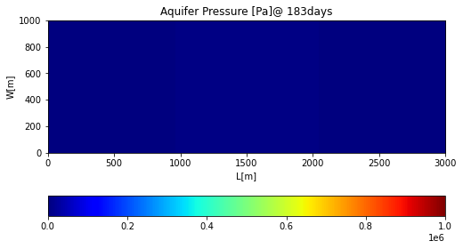

```python
fig = plt.figure(figsize=(8.0, 6.0))
plt.imshow([P_new, P_new], extent = [0, L, 0, W], cmap = 'jet', vmin=0, vmax=1e6)
plt.xlabel('L[m]')
plt.ylabel('W[m]')
plt.title("Aquifer Pressure [Pa]@ {:d}days".format(int(t/86400)))
plt.colorbar(aspect = 20, orientation= 'horizontal', shrink=1)
```